# Viagens nas estações de bicicletas compartilhadas

Autor

Vinicius Viroli Pereira

Data de Publicação

25 de novembro de 2026

# Os dados

Os dados deste trabalho representam viagens realizadas em estações de bicicletas compartilhadas. A base utilizada foi gerada especificamente para o login do autor no contexto da disciplina de Tecnologia de Dados, do curso de Bacharelado em Estatística e Ciência de Dados da Universidade Federal do Paraná (UFPR). Trata-se de um conjunto de dados simulados, desenvolvido para fins didáticos e de aprendizagem das técnicas apresentadas na disciplina.

A unidade de observação é cada estação de bicicletas compartilhadas, identificada por um código único e caracterizada por seu nome, categoria de entorno e número de vagas. Os meses sem registro foram tratados como ausências (NA’s) durante a etapa de conferência e substituídos por zero para os cálculos dos resumos, mantendo a decisão adotada na Lista 03 que utilizou a mesma base de dados e antecedeu o presente trabalho.

O cadastro contém 9 unidades.

Uma unidade presente no cadastro não possui medições registradas no conjunto de viagens. Essa unidade é apresentada na Tabela 1.

Tabela 1: Unidade presente no cadastro sem medições registradas.

| codigo | nome | entorno | vagas |
| --- | --- | --- | --- |
| BK03 | Estação Boqueirão | Residencial | 35 |

A Tabela 2 apresenta as conferências de integridade dos dados, incluindo a quantidade de registros ausentes e as somas anuais informadas no arquivo LEIA-ME. O conjunto de dados empilhado contém 288 registros.

Tabela 2: Quantidade de meses sem registro por ano.

| ano | ausentes |
| --- | --- |
| 2023 | 4 |
| 2024 | 5 |
| 2025 | 2 |

A conferência das somas das viagens por ano é apresentada na Tabela 3:

Tabela 3: Soma anual das viagens por ano.

| ano | soma |
| --- | --- |
| 2023 | 120960 |
| 2024 | 128241 |
| 2025 | 149001 |

# Sazonalidade

A Figura 1 apresenta a média mensal da medida relativa das viagens para cada ano da série analisada.

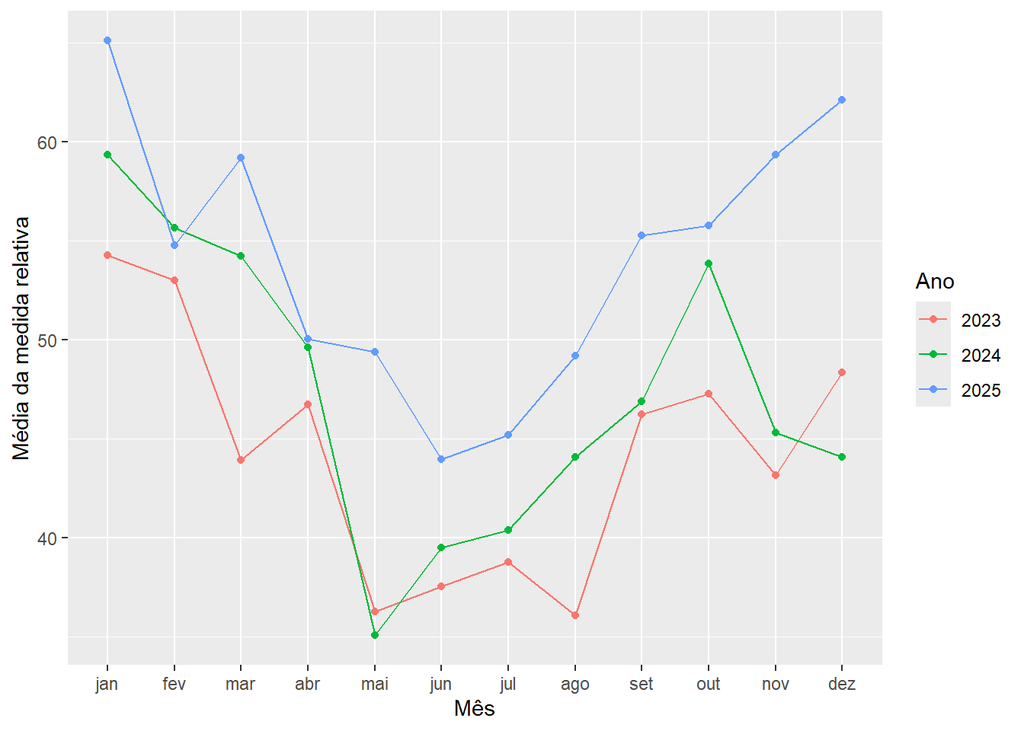

Figura 1: Média mensal da medida relativa das viagens por ano.

Considerando a média dos três anos, o mês com maior média relativa foi janeiro, com média de 59,6. Já o mês com menor média relativa foi maio, com média de 40,26.

# Variação entre 2023 e 2025

A Tabela 4 apresenta o total de viagens e a média da medida relativa para cada ano analisado. A comparação é realizada utilizando a média da medida relativa, e não o total de viagens, porque a medida relativa considera a capacidade das estações (número de vagas), permitindo uma comparação mais adequada entre unidades de tamanhos diferentes.

Tabela 4: Resumo anual da medida relativa e do total de viagens.

| ano | media_relativa | total_viagens |
| --- | --- | --- |
| 2023 | 44,32 | 120960 |
| 2024 | 47,35 | 128241 |
| 2025 | 54,13 | 149001 |

Entre 2023 e 2025, a média da medida relativa aumentou em 22,14%.

## Modelo estatístico (opcional)

Além da análise descritiva, foi ajustado um modelo linear para o logaritmo da medida relativa em função do ano, do mês e da categoria de entorno.

O coeficiente associado ao ano indica uma variação média anual de 9,39%.

O intervalo de confiança de 95% para essa variação vai de 7,77% a 11,03%.

Um resumo do modelo é apresentado a seguir. Em particular, o coeficiente associado ao ano quantifica a variação média anual da medida relativa após controlar simultaneamente os efeitos sazonais dos meses e as diferenças entre categorias de entorno.

```
Call:
lm(formula = log(viagens_relativas) ~ ano + mes + entorno, data = dplyr::filter(dados,
    viagens_relativas > 0))

Residuals:
      Min        1Q    Median        3Q       Max
-0.270215 -0.066534  0.009265  0.070166  0.227376

Coefficients:
                     Estimate Std. Error t value Pr(>|t|)
(Intercept)        -1.774e+02  1.533e+01 -11.567  < 2e-16 ***
ano                 8.975e-02  7.576e-03  11.847  < 2e-16 ***
mesfev             -5.048e-02  3.013e-02  -1.676  0.09500 .
mesmar             -9.618e-02  3.013e-02  -3.193  0.00158 **
mesabr             -1.497e-01  3.013e-02  -4.967 1.23e-06 ***
mesmai             -2.697e-01  3.086e-02  -8.741 2.82e-16 ***
mesjun             -3.820e-01  2.980e-02 -12.817  < 2e-16 ***
mesjul             -3.575e-01  2.980e-02 -11.996  < 2e-16 ***
mesago             -2.887e-01  3.013e-02  -9.584  < 2e-16 ***
messet             -1.436e-01  3.013e-02  -4.765 3.13e-06 ***
mesout             -1.265e-01  2.980e-02  -4.243 3.06e-05 ***
mesnov             -7.947e-02  3.048e-02  -2.607  0.00965 **
mesdez             -9.368e-02  3.012e-02  -3.110  0.00208 **
entornoParque      -4.004e-01  1.436e-02 -27.873  < 2e-16 ***
entornoResidencial -3.057e-01  1.597e-02 -19.136  < 2e-16 ***
---
Signif. codes:  0 '***' 0.001 '**' 0.01 '*' 0.05 '.' 0.1 ' ' 1

Residual standard error: 0.1032 on 262 degrees of freedom
Multiple R-squared:  0.8359,    Adjusted R-squared:  0.8272
F-statistic: 95.34 on 14 and 262 DF,  p-value: < 2.2e-16
```

# Diferenças entre categorias

A distribuição da medida relativa por categoria de entorno é apresentada na Figura 2.

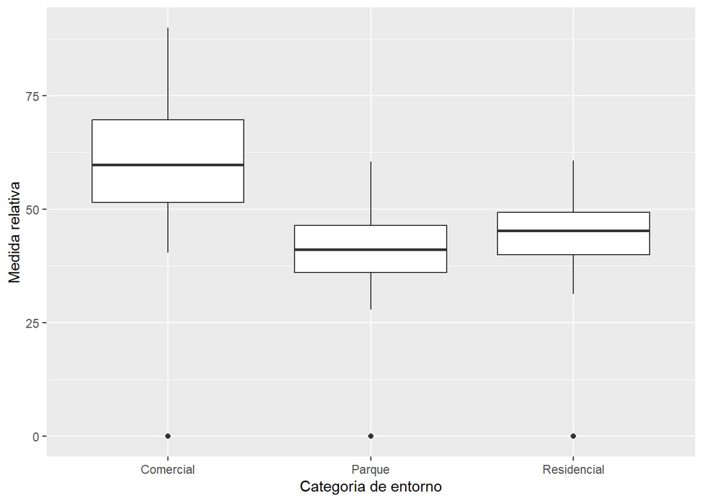

Figura 2: Distribuição da medida relativa por categoria de entorno.

As médias da medida relativa para cada categoria são apresentadas na Tabela 5.

Tabela 5: Média da medida relativa por categoria de entorno.

| entorno | media_relativa |
| --- | --- |
| Comercial | 60,13 |
| Residencial | 44,38 |
| Parque | 39,87 |

A categoria Comercial apresentou a maior média da medida relativa, com valor de 60,13. Por outro lado, a categoria Parque apresentou a menor média, com valor de 39,87. Esses resultados sugerem diferenças no padrão de utilização das estações conforme o tipo de entorno em que estão localizadas.

# As tabelas da Lista 03

Esta seção apresenta as tabelas produzidas originalmente na Lista 03 e incorporadas ao pipeline reprodutível do projeto.

## Por unidade

A Tabela 6 apresenta os resultados consolidados por unidade, incluindo o número de meses com registro, o total anual de viagens e a média da medida relativa.

Tabela 6: Resumo dos indicadores por unidade.

[output not shown]

## Por categoria e ano

A Tabela 7 apresenta o total anual de viagens por categoria de entorno para cada ano da série analisada.

Tabela 7: Total anual de viagens por categoria e ano.

| entorno | 2023 | 2024 | 2025 |
| --- | --- | --- | --- |
| Comercial | 66.560 | 68.210 | 82.448 |
| Parque | 25.094 | 29.256 | 32.284 |
| Residencial | 29.306 | 30.775 | 34.269 |